# RRR - Replicating Resampling with Rsampling

Paulo I Prado, Alexandre Oliveira and Andre Chalom

April 2016

## Overview

This guide is an introduction to the **Rsampling** package, which replicates in R the functions of the *Resampling Stats* add-in for Excel. (http://www.resample.com/) [^1].

These functions are used in a workflow that summarizes the logic behind significance tests:

1. Define a statistic of interest;
2. Define the null hypothesis;
3. Get the statistic of interest distribution under null hypothesis;
4. If the probability of the observed statistic of interest occurring under null hypothesis is lower than a critical value, reject the null hypothesis.

*Resampling Stats*’s main idea is to facilitate the understanding of this logic, by making the user execute each step in a spreadsheet, with the aid of some macros.

**Rsampling**’s package aims at enabling this same training process in R. Keeping the original workflow is favored over performance.

The sections following installation instructions are examples of the simpler and most common applications of **Rsampling**. You may refer to the package help pages to learn about all other functionalities.

## Installation

Rsampling is hosted on CRAN. To install it use

```r
> install.packages("Rsampling")
```

You can also install from the GitHub site, where the project is hosted. To do that use the devtools package function `install_github`:

```r
> library(devtools)
> install_github(repo = 'lageIBUSP/Rsampling')
```

After installation load the package

```r
> library(Rsampling)
```

## Shuffling a column to test difference between groups

The `embauba` data frame contains the data on presence and absence of lianas on *Cecropia* trees of two morphotypes (white and red).

```r
> head(embauba)
  morphotype with.vines
1   VERMELHA      FALSE
2   VERMELHA      FALSE
3   VERMELHA      FALSE
4   VERMELHA      FALSE
5   VERMELHA      FALSE
6   VERMELHA      FALSE
> summary(embauba)
    morphotype with.vines
 BRANCA  :82   Mode :logical
 VERMELHA:70   FALSE:105
               TRUE :47
               NA's :0
```

For more details on the data please refer to help page (`?embauba`).

### Study hypothesis

The original study’s hypothesis is that ants that live within the hollow trunks of *Cecropia* remove lianas from these trees. The prediction is that *Cecropia* trees of the red morphotype would be less infested by lianas than the white ones, because they shelter ant colonies more often. In fact, this difference is observed in the proportions of trees infested by lianas in the sample:

```r
> tapply(embauba$with.vines, embauba$morphotype, mean)
   BRANCA  VERMELHA
0.4878049 0.1000000
```

### Null hypothesis

The null hypothesis is that the proportion of infested trees are equal at the population from where the samples were drawn. Under this hypothesis, a liana has the same chance of occurrence in both morphotypes. We can simulate this null hypothesis by shuffling the presence of lianas between trees in the data table.

### Statistic of interest

For each simulation we have to calculate our **statistic of interest**, which is the difference of infestation by lianas between the two morphotypes. So, we create a function to calculate this statistic:

```r
> emb.si <- function(dataframe){
+     props <- tapply(dataframe$with.vines, dataframe$morphotype, mean)
+     props[[1]] - props[[2]]
+ }
> ## Verifying
> emb.si(embauba)
[1] 0.3878049
```

### Distribution of statistics under the null hypothesis

Then we run the simulation with the function `Rsampling`:

```r
> emb.r <- Rsampling(type = "normal", dataframe = embauba,
+                    statistics = emb.si, cols = 2, ntrials = 1000)
```

**What does this command mean?**

- `type = "normal"` indicates a randomization of a whole data set (the most basic type of randomization, afterwards you’ll see other types).
- `dataframe = embauba` indicates the data table
- `statistics = emb.si` indicates the function that calculates the statistic of interest from the data table.
- `cols = 2` indicates that the randomization must be done over the second column of the data table.
- `ntrials = 1000` indicates the number of simulation repetitions.

The distribution of the statistic of interest at the simulation didn’t even include the observed value:

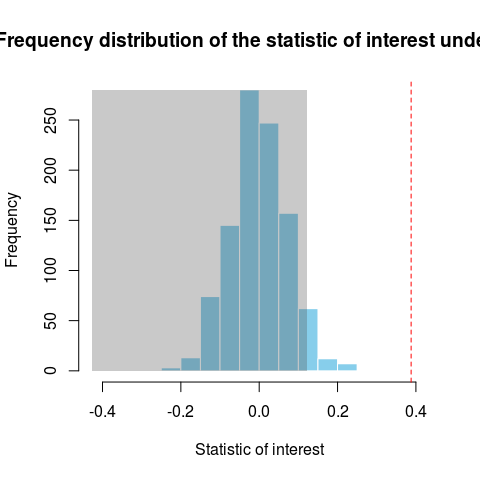

Distribution of the differences between the proportions of red and white *Cecropia* trees with lianas obtained from 1000 simulations of the null hypothesis. The null hypothesis is that the proportion of infested trees are equal at the population from where the samples were drawn. The red line marks the difference observed in the samples and the gray area is the *acceptance region* of the null hypothesis.

```r
> dplot(emb.r, svalue = emb.si(embauba), pside="Greater",
+       main = "Frequency distribution of the statistic of interest under H0",
+       xlab = "Statistic of interest")
```

### Decision: should we reject the null hypothesis?

As usual in the biological sciences, we adopt the criteria of rejecting the null hypothesis if the probability of the statistic of interest under the null hypothesis is under 5% (p < 0.05).

The area not highlighted in gray marks the top 5% of the statistic distribution under the null hypothesis. Thus, if the observed statistic is in the gray area we do not reject the null hypothesis. This is called the *acceptance region* of H0. As the observed value (red line) is outside the acceptance region, H0 can be rejected. You can also check this with a logical test in R:

```r
> sum(emb.r >= emb.si(embauba))/1000 < 0.05
[1] TRUE
```

**Conclusion:** we reject the null hypothesis (p < 0.05).

## Shuffling within rows to test differences within pairs

The dataframe `azteca` contains the number of *Azteca* sp ants recruited by aqueous extracts of old and young leaves of *Cecropia* trees.

```r
> head(azteca)
  plant extract.new extract.old
1     1           5           0
2     2          12           6
3     3          30           5
4     4           0           0
5     5           0           2
6     6           5           2
> summary(azteca)
     plant     extract.new     extract.old
 Min.   : 1   Min.   : 0.00   Min.   : 0.000
 1st Qu.: 6   1st Qu.: 2.00   1st Qu.: 1.000
 Median :11   Median : 4.00   Median : 2.000
 Mean   :11   Mean   :10.05   Mean   : 2.714
 3rd Qu.:16   3rd Qu.:12.00   3rd Qu.: 4.000
 Max.   :21   Max.   :50.00   Max.   :10.000
```

Learn more about the data at its help page (`?azteca`).

### Study hypothesis

The study hypothesis is that recruitment is more intense when a young leaf is damaged. This hypothesis predicts that an extract made from young leaves would recruit more ants than an extract made of old leaves. Indeed this was the outcome of the experiment:

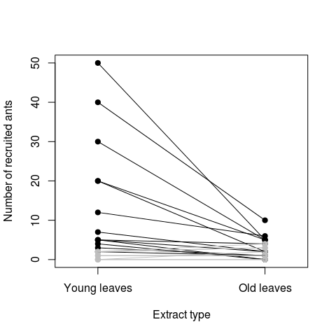

Number ants that were recruited by aqueous extracts of young and old leaves of *Cecropia* trees. The extracts were dropped in paired leaves of *Cecropia* trees that had colonies of *Azteca* ants. The lines link leaves of same experimental pair.

```r
> splot(azteca$extract.new, azteca$extract.old,
+            group.name=c("Young leaves","Old leaves"),
+            ylab="Number of recruited ants",
+            xlab="Extract type")
```

### Null hypothesis

The null hypothesis is that the recruitment caused by each extract is the same. Note that the experiment was paired in order to control for the other sources of variation. Thus, to simulate the null hypothesis we have to shuffle the number of recruited ants **within** each pair of leaves.

### Statistic of interest

For each simulation we calculate our **statistic of interest**, which is the mean of the difference of recruited ants within each pair of leaves. We thus create a function calculate the statistic of interest from the data table:

```r
> azt.si <- function(dataframe){
+     diferencas <- with(dataframe, extract.new - extract.old)
+     mean(diferencas)
+ }
> ## Observed value
> azt.si(azteca)
[1] 7.333333
```

In the experiment the young leaf extract recruited on average 7.3 ants than the old leaf extract, for each pair.

### Distribution of the statistic under null hypothesis

As the pairs are at rows of our dataframe, we simulate the null hypothesis shuffling values within each row:

```r
> azt.r <- Rsampling(type = "within_rows", dataframe = azteca,
+                    statistics = azt.si, cols = 2:3, ntrials = 1000)
```

We changed the argument `type = "within rows"` to indicate that the values are now shuffled within the lines. The argument `cols = 2:3` indicates the columns of the dataframe which contain the counts to be shuffled.

A difference equal to or greater than that observed was very rare in the distribution of the statistic of interest:

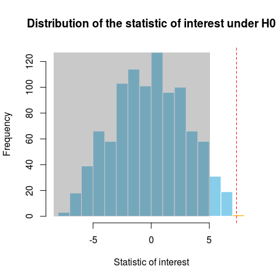

Frequency distributions of the difference of the number of ants recruited by the two types of extracts in 1000 simulations of the null hypothesis. The null hypothesis is that both extracts recruit ants equally. The red line marks the difference observed in the samples and the gray area is the *acceptance region* of the null hypothesis.

```r
> dplot(azt.r, svalue = azt.si(azteca), pside="Greater",
+       main = "Distribution of the statistic of interest under H0",
+       xlab = "Statistic of interest")
```

### Decision: should we reject the null hypothesis?

Again, the distribution of the statistic of interest shows that the observed value of the statistic is outside the acceptance region for the null hypothesis under our significance criterion (5% chance of error). The same result is found with the following logical test:

```r
> sum(azt.r >= azt.si(azteca))/1000 < 0.05
[1] TRUE
```

**Conclusion:** we reject the null hypothesis (p<0.05).

#### Coda: one-sided and double-tailed tests.

So far we have tested the hypothesis that a value **equal to or higher** than the observed can be generated by the null hypothesis. We call this an **one-tailed** or **one-sided** test, as it would also be if our aim was testing if an equal or smaller value could be generated under null hypothesis. In one-sided tests, the acceptance region comprises the null distribution except its 5% more extreme values.

But we might investigate differences among groups without specifying its direction. For example, prior knowledge could suggest the hypothesis that extracts of young and old leaves should recruit different numbers of ants, but without any expectation concerning which extract would recruit more. This is a case for a **two-tailed** or **two-sided** test. In a two-tailed test the acceptance region is the center of the null distribution, excluding their 2.5% most extreme values at each side:

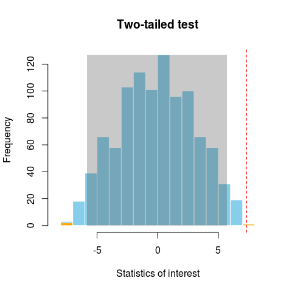

Frequency distributions of the difference of the number of ants recruited by the two types of extracts in 1000 simulations of the null hypothesis. The null hypothesis is that both extracts recruit ants equally. The red line marks the difference observed in the samples and the gray area is the *acceptance region* of the null hypothesis for a two-tailed test

```r
> dplot(azt.r, svalue = azt.si(azteca), pside="Two sided",
+       main = "Two-tailed test",
+       xlab = "Statistics of interest")
```

## Randomization with replacement

The data frame `peucetia` contains data from an experiment of substrate choice by spiders of the genus *Peucetia*. Twenty-seven spiders were kept in Petri dishes covered with two substrata (plant leaves with and without glandular “hairs” - trichomes - ). Every plate was inspected six times to check if each spider was on the leaves with or without trichomes.

```r
> head(peucetia)
     t1    t2    t3    t4    t5    t6
1 FALSE FALSE FALSE FALSE FALSE FALSE
2 FALSE FALSE FALSE FALSE FALSE FALSE
3 FALSE FALSE FALSE FALSE FALSE FALSE
4  TRUE  TRUE FALSE FALSE FALSE FALSE
5  TRUE  TRUE  TRUE FALSE FALSE FALSE
6 FALSE FALSE FALSE  TRUE  TRUE  TRUE
```

To learn more about the data check its help page (`?peucetia`).

### Study hypothesis

The study hypothesis is that spiders prefer to hunt in plants with glandular hairs, where catching prey is easier. The predicted outcome of the experiment is that spiders should be recorded most of the time on leaves with trichomes. In fact, most of the spiders were on the leaves with trichomes in at least 4 out of six inspections:

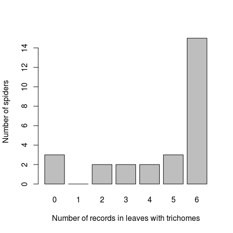

Number of inspections each of 27 spiders were recorded on leaves with trichomes in a experiment of preference for two types of substrata (leaves with or without trichomes). The substrate of each spider was checked six times.

```r
> ## Number of records in leaves with trichomes
> n.insp <- apply(peucetia, 1, sum)
> barplot(table(factor(n.insp, levels=0:6)),
+         xlab="Number of records in leaves with trichomes",
+         ylab="Number of spiders")
```

### Null hypothesis

The null hypothesis is that there is no preference for any substrate. Half of the area of each plate was covered with each leaf type. Hence the null expectation is that the spiders would be in the area covered by leaves with trichomes in half of the inspections. This expectation assumes that each inspection is an independent event.

### Statistics of interest

For each simulation we have to calculate our **statistic of interest**. In this case we choose the average number of inspections where the spiders were recorded on leaves with trichomes. Thus we build a function to calculate this statistics from data:

```r
> peu.si <- function(dataframe){
+     mean(apply(dataframe, 1, sum))
+ }
> ## Observed value
> peu.si(peucetia)
[1] 4.555556
```

The spiders were recorded on average 4.56 of the six inspections on the area covered with leaves with trichomes.

### Distribution of the statistic under the null hypothesis

To simulate our null hypothesis, we create a *data frame* with the same structure, wherein each spider is on leaves with trichomes on half of the inspections.

```r
> peu.H0 <- matrix( rep(c(TRUE,FALSE), each = 3),
+                  nrow = nrow(peucetia), ncol = ncol(peucetia), byrow=TRUE)
> ## Converts in data.frame
> peu.H0 <- data.frame(peu.H0)
> ## verifying
> head(peu.H0)
    X1   X2   X3    X4    X5    X6
1 TRUE TRUE TRUE FALSE FALSE FALSE
2 TRUE TRUE TRUE FALSE FALSE FALSE
3 TRUE TRUE TRUE FALSE FALSE FALSE
4 TRUE TRUE TRUE FALSE FALSE FALSE
5 TRUE TRUE TRUE FALSE FALSE FALSE
6 TRUE TRUE TRUE FALSE FALSE FALSE
```

Then we simulate the null hypothesis by sampling each line with replacement [^2]:

```r
> peu.r <- Rsampling(type = "within_rows", dataframe = peu.H0,
+                    statistics = peu.si, ntrials = 1000, replace=TRUE)
```

The argument `replace = TRUE` indicates sampling with replacement. In this case, this is a drawn of an independent position for each spider at each inspection. Therefore the probability of each spider being at the area covered by leaves with trichomes is 0.5 per drawing.

An average number of records in leaves with trichomes equal to or greater than that observed did not occur at the simulated distribution of our statistic of interest:

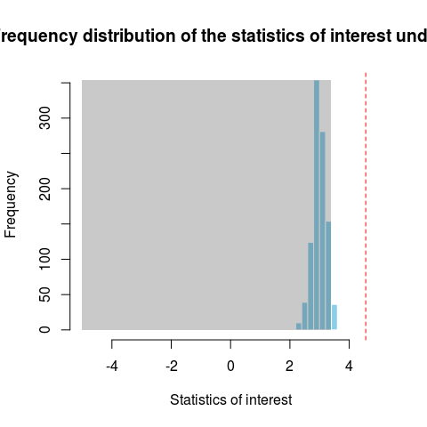

Frequency distribution of the mean number of records of spiders on leaves with trichomes in 1000 simulations of the null hypothesis that there is no preference for substrata. The red line marks the observed average in the experiment and the gray area is the *acceptance region* of the null hypothesis.

```r
> dplot(peu.r, svalue = peu.si(peucetia), pside="Greater",
+       main = "Frequency distribution of the statistics of interest under H0",
+       xlab = "Statistics of interest")
```

### Decision: should we reject the null hypothesis?

Again we have a one-tailed test, and the observed value of the statistic of interest fell outside the region of acceptance of the null hypothesis (5%). We can check this with the logical test of our significance criterion:

```r
> sum(peu.r >= peu.si(peucetia))/1000 < 0.05
[1] TRUE
```

**Conclusion:** we reject the null hypothesis (p < 0.05).